# pause

Stop `cy` commands from running and allow interaction with the application under test. You can then "resume" running all commands or choose to step through the "next" commands from the Command Log.

> This does not set a `debugger` in your code, unlike `.debug()`

## Syntax

```javascript
.pause()
.pause(options)

cy.pause()
cy.pause(options)
```

### Usage

**Correct Usage**

```javascript
cy.pause().getCookie('app') // Pause at the beginning of commands
cy.get('nav').pause() // Pause after the 'get' commands yield
```

### Arguments

**options** *(Object)*

Pass in an options object to change the default behavior of `.pause()`.

| Option | Default | Description |
| --- | --- | --- |
| `log` | `true` | Displays the command in the [Command log](https://docs.cypress.io/guides/core-concepts/test-runner#Command-Log) |

### Yields

- `.pause()` yields the same subject it was given from the previous command.

## Examples

### No Args

#### Pause after assertion

```javascript
cy.get('a')
  .should('have.attr', 'href')
  .and('match', /dashboard/)
  .pause()
cy.get('button').should('not.be.disabled')
```

## Rules

### Requirements

- `.pause()` can be chained off of `cy` or off another command.

### Assertions

- `.pause()` is a utility command.
- `.pause()` will not run assertions. Assertions will pass through as if this command did not exist.

### Timeouts

- `.pause()` cannot time out.

## Command Log

### Pause and step through each `.click()` command

```javascript
cy.get('#action-canvas')
  .click(80, 75)
  .pause()
  .click(170, 75)
  .click(80, 165)
  .click(100, 185)
  .click(125, 190)
  .click(150, 185)
  .click(170, 165)
```

The commands above will display in the Command Log as:

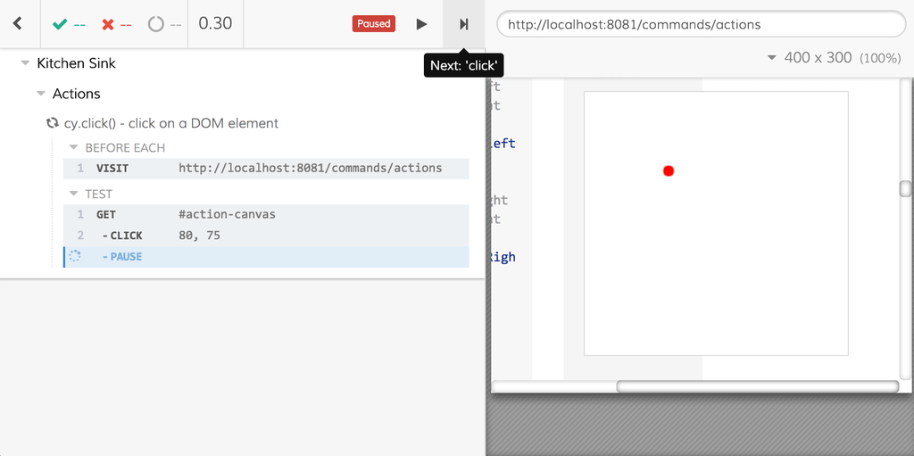

When clicking on "Next: 'click'" at the top of the Command Log, the Command Log will run only the next command and pause again.

#### Click "Next"

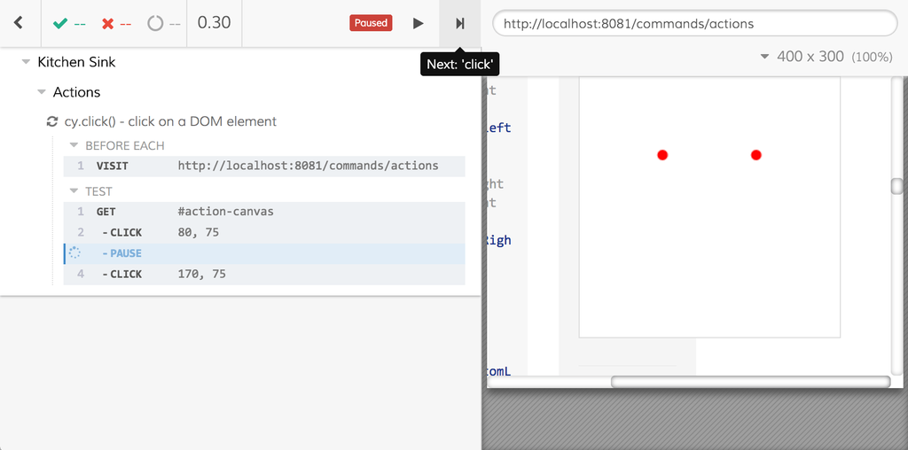

#### Click "Next" again

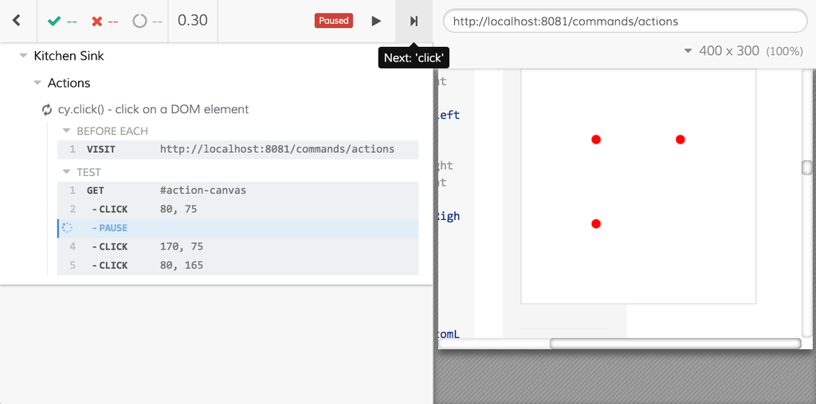

#### Click "Next" again

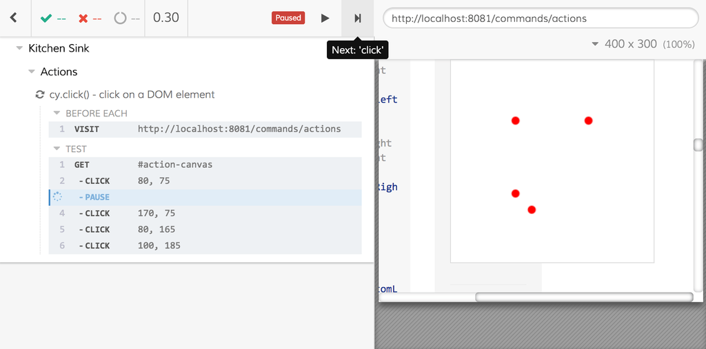

#### Click "Next" again

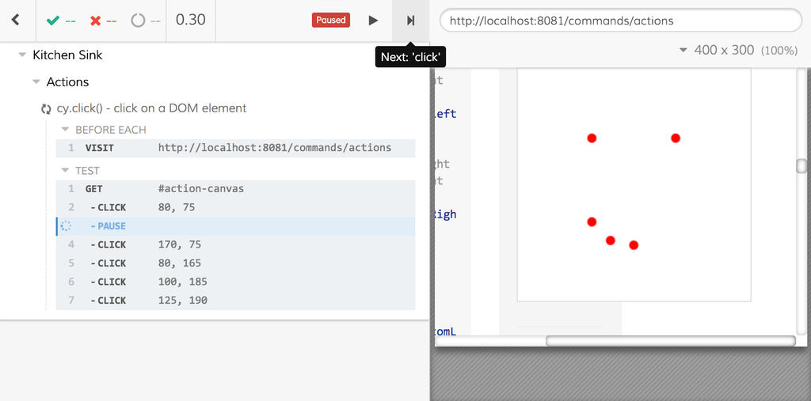

#### Click "Next" again

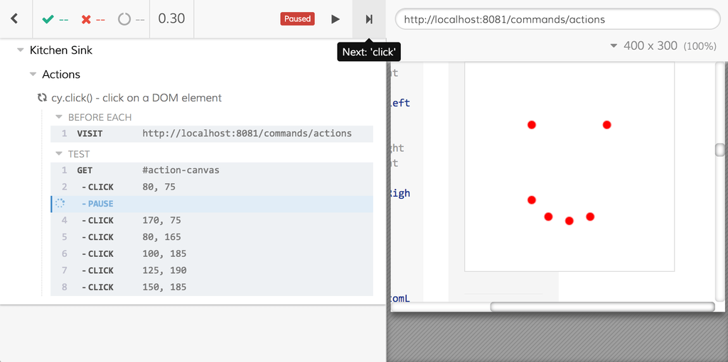

#### Click "Next" again, then 'Resume'

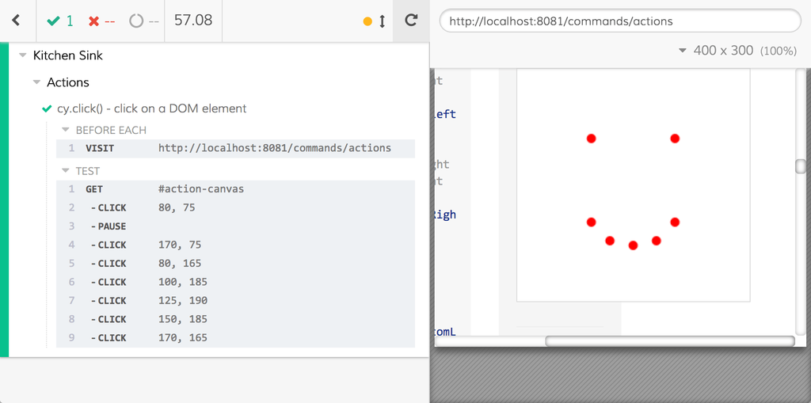

## See also

- [Dashboard](https://on.cypress.io/dashboard)
- `cy.debug()`
- `cy.log()`
- `cy.screenshot()`

© 2017 Cypress.io  
Licensed under the MIT License.  
https://docs.cypress.io/api/commands/pause